# The MITOMAP Concordance

Jeremy Leipzig

August 13, 2015

MITOMAP conducts periodic analysis of all full length (>15.4kbp) mitochondrial sequences in GenBank. This involves processing the nearly 30k sequences through MITOMASTER. While no means an unbiased survey, the GenBank set offers some interesting opportunities to study human mitochondrial variability.

The fully reproducible source code for this project is located at: https://github.research.chop.edu/leipzigj/mitomap_concordance

```r
library(ggplot2)
library(dplyr)
library(RPostgreSQL)
library(stringr)
library(SNPlocs.Hsapiens.dbSNP141.GRCh38)
library(gdsfmt)
library(SNPRelate)
library(Matrix)
library(knitr)
library(RColorBrewer)
library(Biostrings)
library(arules)
library(reshape2)
library(repmis)
library(DT)
library(BSgenome)
library(VennDiagram)

load("mitomap.RData")
source("common.R")

# the pcas are very slow so set this to 500 for a sparse quick plot, 5000 for a deep slow one
MASTER_SAMPLE_NUMBER<-4500

palette <- c("dodgerblue1", "skyblue4", "chocolate1", "seagreen4",
"bisque3", "red4", "purple4", "mediumpurple3",
"maroon", "dodgerblue4", "skyblue2", "darkcyan",
"darkslategray3", "lightgreen", "bisque",
"palevioletred1", "black", "gray79", "lightsalmon4",
"darkgoldenrod1")
```

# Overview

There are 10046 mutations in the GenBank set over 8012 which is a rate of 0.4835828 per bp. 2859 of these are singletons belonging to only one sequence.

So in contrast to the nuclear genes 51,217,066 rs numbers in dbSNP out of 3,064,641,871 non-N bases which is a rate of 0.0167123

## For comparison, how many MT snps are in dbSNP?

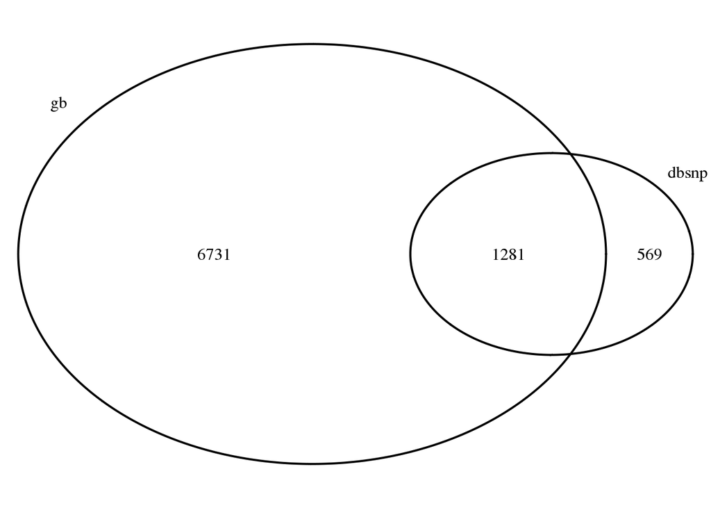

```r
snps <- SNPlocs.Hsapiens.dbSNP141.GRCh38
chMTsnps <- snplocs(snps,"chMT")
chMTlocs<- unique(sort(chMTsnps$loc))
gblocs<-unique(sort(gball$tpos))

notingb<-!(chMTlocs %in% gblocs)

venn<-venn.diagram(list(gb=gblocs,dbsnp=chMTlocs),filename=NULL)
grid.draw(venn)
```

There are 1850 mitochondrial snp positions in dbSNP and 8012 in the GenBank set.

There are an alarming number of SNPs in dbSNP that are missing from the GenBank set (569) but it does not appear they are clustered.

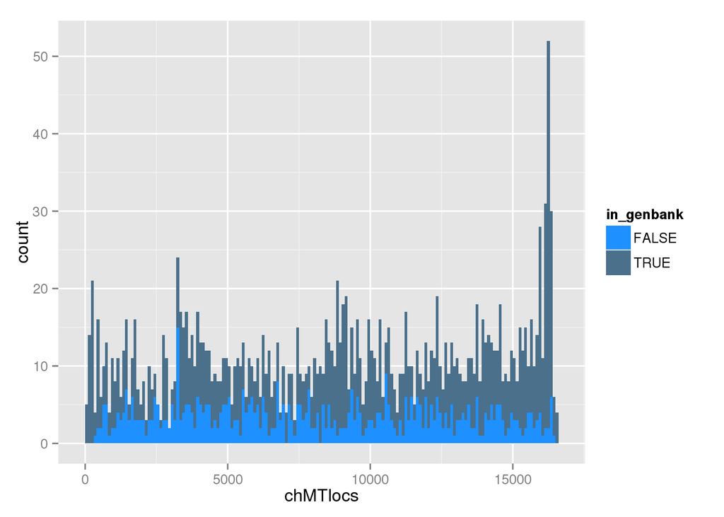

```r
chmt<-data.frame(chMTlocs)
chmt$in_genbank<-chMTlocs %in% gblocs
ggplot(chmt,aes(chMTlocs))+geom_bar(aes(fill=in_genbank),binwidth=100)+scale_fill_manual(values=palette)
```

# Variation

There are 10046 distinct mutations in the gb set over 8012 positions.

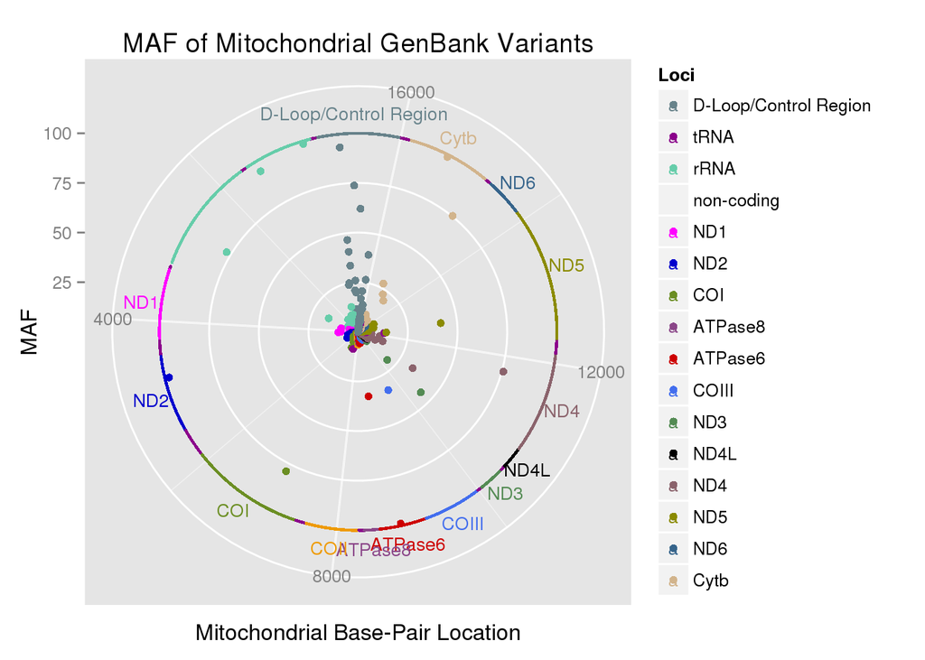

```r
#ggplot(data=hist_pos,aes(pos,variants))+geom_point(stat="identity")
#http://www.gettinggeneticsdone.com/2013/11/a-mitochondrial-manhattan-plot.html
#https://github.com/hadley/ggplot2/wiki/Plotting-Mitochondrial-Genetic-Association-Results

by_pos <- group_by(genbank_count, pos, locus, type, pretty_name)
hist_pos <- summarise(by_pos,maf=sum(cnt)*100/nrow(gbhap),ln_tot=log(sum(cnt)))

group_by(gene_lines,pretty_name) %>%   filter(pretty_name != 'rRNA' & pretty_name != 'tRNA' & pretty_name != 'non-coding') %>% summarize(pos=mean(pos)) -> bdries
bdries[bdries$pretty_name=='D-Loop/Control Region',"pos"]<-50
bdries$y<-110

colours <- c("D-Loop/Control Region" = "lightblue4", "tRNA" = "magenta4", "rRNA" = "mediumaquamarine", "Non-Coding" = "sienna4", "ND1" = "magenta", "ND2" = "mediumblue", "COI" = "olivedrab", "COII" = "orange2", "ATPase8" = "orchid4", "ATPase6" = "red3", "COIII" = "royalblue2", "ND3" = "palegreen4", "ND4L" = "grey0", "ND4" = "pink4", "ND5" = "yellow4", "ND6" = "steelblue4", "Cytb" = "tan","red")

hist_pos$color<-colours[hist_pos$pretty_name]
gene_lines$color<-colours[gene_lines$pretty_name]

ggplot(hist_pos, aes(x = pos,y = maf,color = pretty_name)) +
  geom_point() +
  coord_polar(direction = -1) +
  geom_point(data=gene_lines,aes(pos,y,color = pretty_name),size=0.8) +
  scale_colour_manual(values = colours,"Loci",breaks = c("D-Loop/Control Region","tRNA","rRNA","non-coding","ND1","ND2","COI","COIbyI","ATPase8","ATPase6","COIII","ND3","ND4L","ND4","ND5","ND6","Cytb"), labels = c("D-Loop/Control Region","tRNA","rRNA","non-coding","ND1","ND2","COI","COII","ATPase8","ATPase6","COIII","ND3","ND4L","ND4","ND5","ND6","Cytb")) +
  xlab("Mitochondrial Base-Pair Location") +
  ylab("MAF") +
  ggtitle("MAF of Mitochondrial GenBank Variants") +
  layer(geom="text",mapping =aes(pos,y,label = pretty_name),data = bdries,size=3.5)
```

# Top 30 Most common variants

There are 30589 GenBank sequences. Most the common variants in these are those that distinguish the rCRS sequence.

As we can see, despite what this paper says A8860G is not a rare polymorphism at all. http://www.ncbi.nlm.nih.gov/pmc/articles/PMC3258716/

```r
by_var_group <- group_by(genbank_count, pos, ref, alt, snpid, locus, type)

by_var_cnt <- summarise(by_var_group,variants=sum(cnt))

known_crs_snps<-"A73G, T146C, T152C, T195C, G247A, A263G, A523d, C524d, A750G, G769A, T825A, G1018A, A1438G, A2706G, G2758A, T2885C, C3594T, A4104G, C4312T, A4769G, C7028T, A7146G, C7256T, G7521A, C8468T, C8655T, A8701G, A8860G, T9540C, A10398G, C10664T, G10688A, T10810C, T10873C, T10915C, G11719A, G11914A, C12705T, A13105G, A13276G, C13506T, C13650T, C14766T, A15326G, G16129A, C16187T, T16189C, C16223T, A16230G, C16278T, T16311C, T16519C"
known_crs<-unlist(str_split(str_replace_all(known_crs_snps,' ',''),','))

by_var_cnt$known<-by_var_cnt$snpid %in% known_crs
datatable(by_var_cnt[order(-by_var_cnt$variants),][1:30,],rownames=FALSE)
```

| pos | ref | alt | snpid | locus | type | variants | known |
| --- | --- | --- | --- | --- | --- | --- | --- |
| 8860 | A | G | A8860G | ATPase6 | coding | 30265 | True |
| 15326 | A | G | A15326G | Cytb | coding | 30250 | True |
| 750 | A | G | A750G | 12S | rRNA | 30156 | True |
| 4769 | A | G | A4769G | ND2 | coding | 29926 | True |
| 1438 | A | G | A1438G | 12S | rRNA | 28934 | True |
| 263 | A | G | A263G | HVS2 | non-coding | 28559 | True |
| 7028 | C | T | C7028T | COI | coding | 24177 | True |
| 2706 | A | G | A2706G | 16S | rRNA | 23675 | True |
| 11719 | G | A | G11719A | ND4 | coding | 23169 | True |
| 14766 | C | T | C14766T | Cytb | coding | 23043 | True |

[output cut: 20 more lines]

# Most and least conserved loci (over 20 bp, beware overlapping annotation)

```r
get_length<-function(locus){
  return(as.integer(loci[loci$common_name==locus[1],"length"]))
}
#using our loci calling scheme
get_eligible_length<-function(locus){
  alocus<-locus[1]
  return(as.integer(nrow(subset(gene_lines,locus==alocus))))
}
#weight by total variants
group_by(genbank_count, locus, type) %>% mutate(length=get_eligible_length(locus)) %>% summarise(total_variants=sum(cnt),rate=round(sum(cnt)/mean(length),digits=2),length=mean(length)) -> loci_conservation_total_weight

#weight by distinct variant positions
group_by(genbank_count, locus, type) %>% mutate(length=get_eligible_length(locus)) %>% summarise(variant_pos=n_distinct(pos),rate=round(n_distinct(pos)/mean(length),digits=2),length=mean(length)) -> loci_conservation
```

## Least Conserved Loci (over 20bp)

```r
datatable(subset(loci_conservation[order(-loci_conservation$rate),],length>20)[1:10,],rownames=FALSE)
```

| locus | type | variant_pos | rate | length |
| --- | --- | --- | --- | --- |
| NC7 | non-coding | 24 | 0.96 | 25 |
| TFX | non-coding | 24 | 0.96 | 25 |
| D-Loop | non-coding | 81 | 0.94 | 86 |
| TFY | non-coding | 19 | 0.83 | 23 |
| TFH | non-coding | 18 | 0.82 | 22 |
| T | tRNA | 51 | 0.77 | 66 |
| HVS1 | non-coding | 248 | 0.75 | 329 |
| ATPase6 | coding | 465 | 0.73 | 635 |
| HVS2 | non-coding | 148 | 0.73 | 203 |
| ATPase8 | coding | 146 | 0.71 | 207 |

## Most Conserved Loci (over 20bp)

```r
datatable(subset(loci_conservation[order(loci_conservation$rate),],length>20)[1:10,],rownames=FALSE)
```

| locus | type | variant_pos | rate | length |
| --- | --- | --- | --- | --- |
| L(UUA/G) | tRNA | 7 | 0.15 | 48 |
| Y | tRNA | 12 | 0.18 | 66 |
| N | tRNA | 15 | 0.21 | 73 |
| M | tRNA | 15 | 0.22 | 68 |
| TER | non-coding | 6 | 0.23 | 26 |
| E | tRNA | 18 | 0.26 | 69 |
| R | tRNA | 19 | 0.29 | 65 |
| I | tRNA | 21 | 0.3 | 69 |
| 16S | rRNA | 493 | 0.32 | 1535 |
| 12S | rRNA | 311 | 0.33 | 954 |

## Variation rate by type

Multiple regressions are evident by locus type

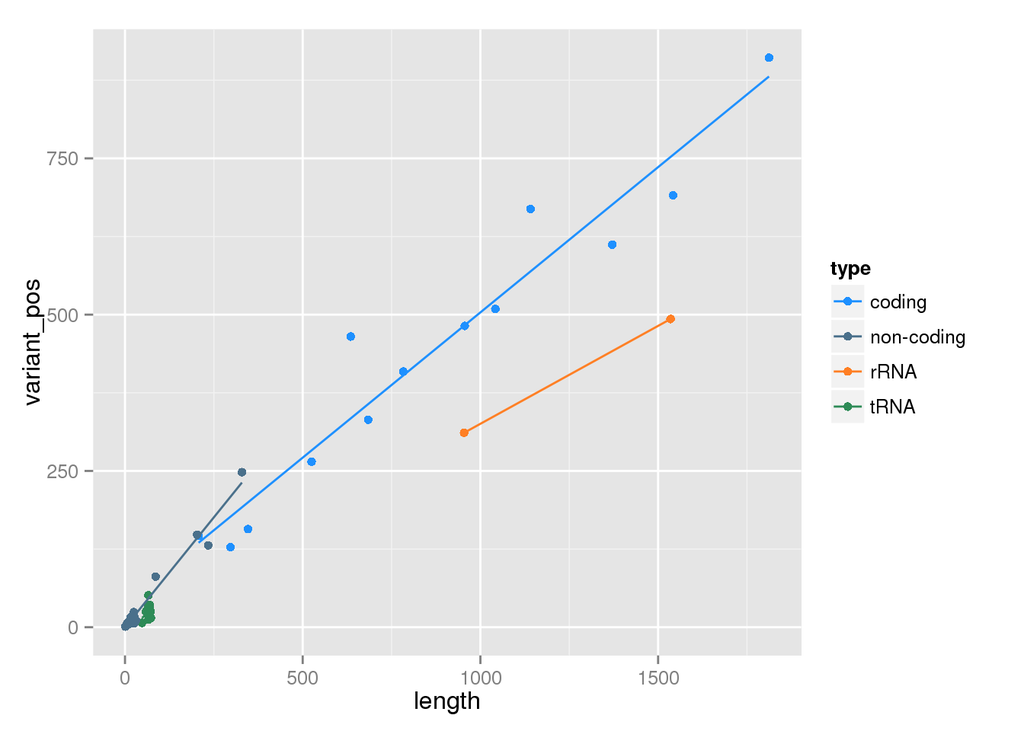

```r
ggplot(loci_conservation,aes(length,variant_pos,color=type))+geom_point()+geom_smooth( method=lm, se=FALSE)+scale_color_manual(values=palette)
```

# Coding genes

## Ti/Tv

What is the Ti/Tv ratio? In the human genome the ratio is 2.1. Rates

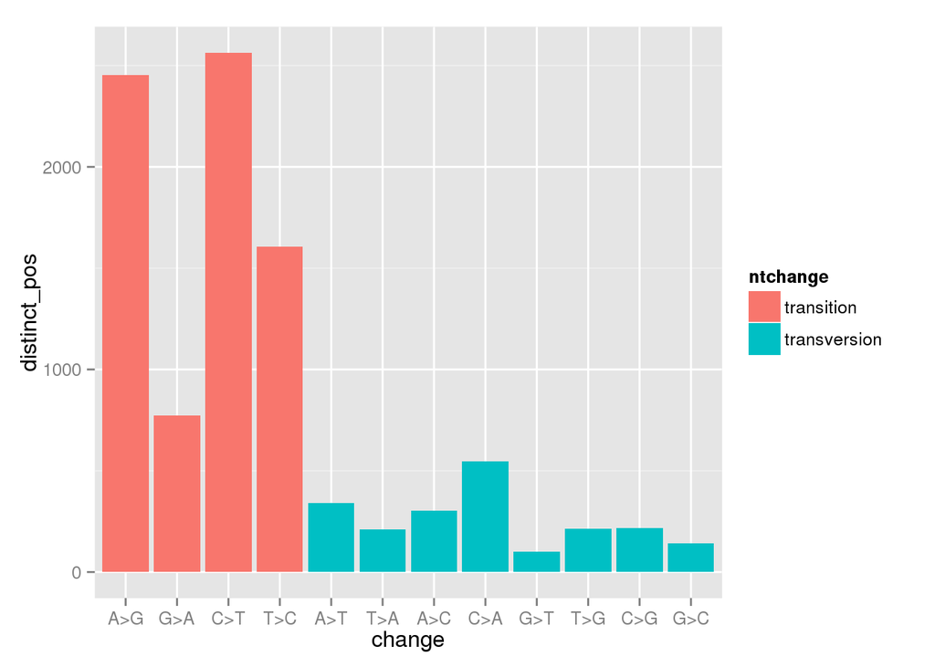

```r
gball %>% filter(ntchange == 'transition' | ntchange == 'transversion') %>% group_by(ntchange,tnt,qnt) %>% summarize(total_events=n(),distinct_pos=n_distinct(tpos)) %>% mutate(change=paste(tnt,">",qnt,sep="")) %>% arrange(desc(ntchange)) -> titv
titv$change<-factor(titv$change,levels=c("A>G","G>A","C>T","T>C","A>T","T>A","A>C","C>A","G>T","T>G","C>G","G>C"))
ggplot(titv,aes(change,distinct_pos))+geom_bar(stat="identity",aes(fill=ntchange))
```

The Ti/Tv ratio depends on how whether we weight the positions

```r
gball %>% filter(ntchange == 'transition' | ntchange == 'transversion') %>% group_by(ntchange) %>% summarize(total_events=n(),distinct_pos=n_distinct(tpos)) -> calc_titv
post_calc<-rbind(calc_titv,data.frame(ntchange="Ti/Tv",total_events=calc_titv$total_events[1]/calc_titv$total_events[2],distinct_pos=calc_titv$distinct_pos[1]/calc_titv$distinct_pos[2]))
t_calc<-as.data.frame(t(post_calc)[-1,])
names(t_calc)<-c("transitions","transversions","Ti/Tv")
t_calc$transitions<-as.integer(as.character(t_calc$transitions))
t_calc$transversions<-as.integer(as.character(t_calc$transversions))
datatable(t_calc,rownames=TRUE)
```

|  | transitions | transversions | Ti/Tv |
| --- | --- | --- | --- |
| total_events | 976272 | 33871 | 28.82324 |
| distinct_pos | 7397 | 1889 | 3.915828 |

## Ka/Ks

Ny/Ns is the predecessor to Ka/Ks.

```r
gball %>% mutate(syn=str_extract(cal_aachange,'((non-)?syn)')) %>% filter(!is.na(syn)) %>% group_by(syn) %>% summarize(total_events=n(),total_positions=n_distinct(tpos)) -> kaks
datatable(kaks,rownames=FALSE)
```

| syn | total_events | total_positions |
| --- | --- | --- |
| non-syn | 196163 | 2264 |
| syn | 374083 | 3680 |

This ratio is 0.5243836 by events 0.6152174

By gene

```r
gball %>% mutate(syn=str_extract(cal_aachange,'((non-)?syn)')) %>% filter(!is.na(syn)) %>% select(tpos,syn) %>% group_by(tpos,syn) %>% summarize(sequences=n()) -> aachange
names(aachange)<-c("pos","change","sequences")
annoaa<-merge(aachange,gene_lines,by="pos",all.x = TRUE)
bygene<-table(annoaa$locus,annoaa$change)[rowSums(table(annoaa$locus,annoaa$change))>30,]
bygene_df<-data.frame(Gene=row.names(bygene),"non-syn"=bygene[,"non-syn"],syn=bygene[,"syn"])
datatable(bygene_df,rownames=FALSE)
```

| Gene | non.syn | syn |
| --- | --- | --- |
| ATPase6 | 262 | 222 |
| ATPase8 | 90 | 64 |
| COI | 204 | 494 |
| COII | 118 | 218 |
| COIII | 177 | 242 |
| Cytb | 325 | 374 |
| ND1 | 180 | 315 |
| ND2 | 206 | 323 |
| ND3 | 54 | 106 |
| ND4 | 166 | 456 |

[output cut: 3 more lines]

# Population genetics

## The breakdown of GenBank sequences by region

```r
datatable(data.frame(table(gbhap$region)),rownames=FALSE,colnames=c("Region","Freq"))
```

| Region | Freq |
| --- | --- |
| Africa | 3893 |
| Asia | 10698 |
| Europe | 15998 |

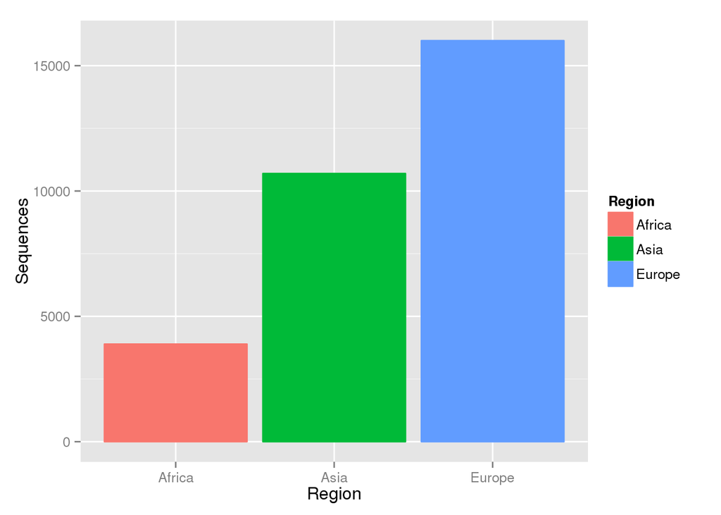

```r
by_region_freq<-as.data.frame(table(gbhap$region))
names(by_region_freq)<-c("Region","Sequences")
ggplot(by_region_freq,aes(Region,Sequences,color=Region))+geom_bar(stat="identity",aes(fill=Region))
```

## The breakdown of GenBank sequences by major haplogroup

```r
datatable(data.frame(table(paste(gbhap$region,gbhap$prefix))),rownames=FALSE,colnames=c("Region/Hap","Freq"))
```

| Region/Hap | Freq |
| --- | --- |
| Africa L0 | 1047 |
| Africa L1 | 710 |
| Africa L2 | 863 |
| Africa L3 | 1160 |
| Africa L4 | 65 |
| Africa L5 | 36 |
| Africa L6 | 12 |
| Asia A | 888 |
| Asia B | 2256 |
| Asia C | 959 |

[output cut: 23 more lines]

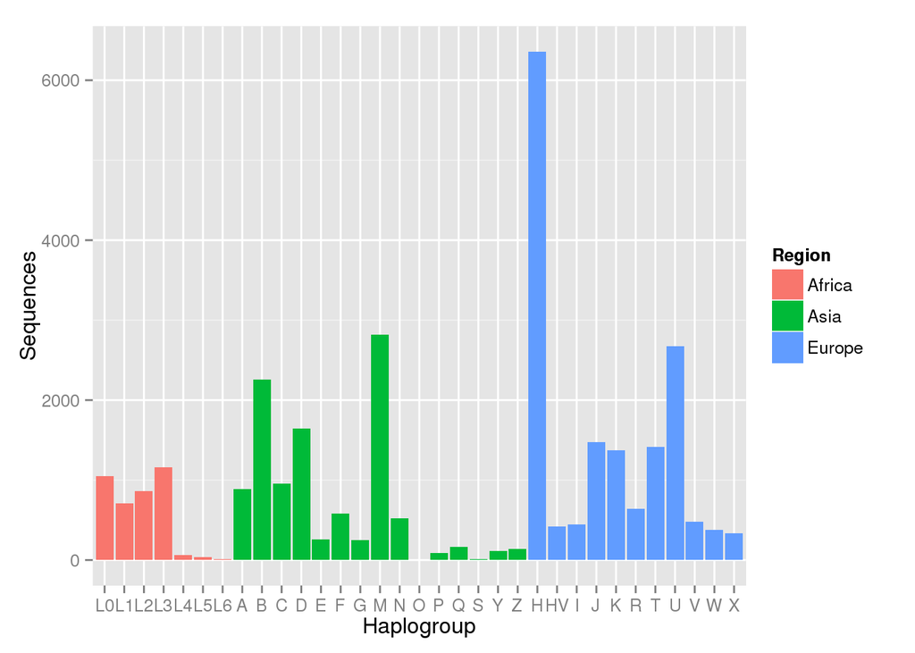

```r
by_prefix_freq<-as.data.frame(table(paste(gbhap$region,gbhap$prefix)))
names(by_prefix_freq)<-c("Haplogroup","Sequences")

by_prefix_split<-cbind(colsplit(by_prefix_freq$Haplogroup, ' ', names =  c('Region','Haplogroup')),by_prefix_freq$Sequences)
names(by_prefix_split)<-c("Region","Haplogroup","Sequences")

by_prefix_split$Haplogroup<-factor(by_prefix_split$Haplogroup,levels=by_prefix_split$Haplogroup)
ggplot(by_prefix_split,aes(Haplogroup,Sequences))+geom_bar(stat="identity",aes(fill=Region))
```

# PCA

How do the genbank sequences stratify using a Principal Component Analysis? We would expect the major haplogroups to cluster.

PCA is really a geometric operation in which they use an operation to find a few which variables tend to flock together, starting with the one that produces the most variance. You can generally a lot of principal components but generally you just look at the first two to keep things in 2D.

“The functions in SNPRelate for PCA include calculating the genetic covariance matrix from genotypes, computing the correlation coefficients between sample loadings and genotypes for each SNP, calculating SNP eigenvectors (loadings), and estimating the sample loadings of a new dataset from specified SNP eigenvectors.”

In a normal PCA the covariance matrix is composed of scalars, but you can generate a PCA of SNPs for biallelic you would generally score homozygous alternate as 2, hemizygous as 1, and all reference as 0. With the mitochondria we just score REF and ALT.

## All regions

```r
#The minimum required variables are

#sample.id, a unique identifier for each sample.
#snp.id, a unique identifier for each SNP.
#snp.position, the base position of each SNP on the chromosome, and 0 for unknown position; it does not allow NA.
#snp.chromosome
#genotype, a SNP genotypic matrix. SNP-major mode: nsample×nsnp, individual-major mode: nsnp×nsample.
# Create a gds file
# The first argument should be a numeric matrix for SNP genotypes. There are possible values stored in the input genotype matrix: 0, 1, 2 and other values. “0” indicates two B alleles, “1” indicates one A allele and one B allele, “2” indicates two A alleles, and other values indicate a missing genotype. The SNP matrix can be either nsample×nsnp (snpfirstdim=FALSE, the argument in snpgdsCreateGeno()) or nsnp×nsample (snpfirstdim=TRUE).


#can we reduce this a bit?
snpidsForPCA<-table(gbfac$snpid)[intersect(which(table(gbfac$snpid)<20000),which(table(gbfac$snpid)>20))]

sparsey<-sparseMatrix(i = as.numeric(gbfac$genbank_id), j = as.numeric(gbfac$snpid))

#convert logical matrix into 0's and 1's (not biallelic anyway)
#haha genius https://stat.ethz.ch/pipermail/r-help/2011-January/265121.html
numsparsey<-1*as.matrix(sparsey)

#extract the position 73 from A73G
pos<-as.numeric(gsub("[A-Z]+([0-9]+).+", "\\1", levels(gbfac$snpid)))

#extract the G from A73G
alleles<-as.character(gsub("[A-Z]+[0-9]+(.+)", "\\1", levels(gbfac$snpid)))

#create the gds file
#26 is MT FWIW
if (! file.exists("mitogb.gds")){
  snpgdsCreateGeno("mitogb.gds", genmat = numsparsey,
      sample.id = levels(gbfac$genbank_id), snp.id = levels(gbfac$snpid),
      snp.chromosome = rep(26,length(levels(gbfac$snpid))),
      snp.position = pos,
      snp.allele = alleles, snpfirstdim=FALSE)
}

#this is weirdly sensitive about reopening the same file
if(!exists("genofile")){
  genofile <- snpgdsOpen("mitogb.gds",readonly=TRUE)
}
#take all snps
snp_subset<-levels(gbfac$snpid)


if(MASTER_SAMPLE_NUMBER){
  sample_subset<-levels(gbfac$genbank_id)[sample(1:length(levels(gbfac$genbank_id)),MASTER_SAMPLE_NUMBER)]
}else{
  sample_subset<-levels(gbfac$genbank_id)
}

PCA<-snpgdsPCA(genofile,autosome.only=FALSE,num.thread=16,eigen.cnt=2,sample.id = sample_subset,snp.id = snp_subset)
```

```
## Principal Component Analysis (PCA) on SNP genotypes:
## Removing 4531 SNPs (monomorphic: TRUE, < MAF: NaN, or > missing rate: NaN)
## Working space: 4500 samples, 5515 SNPs
##  Using 16 (CPU) cores
## PCA: the sum of all working genotypes (0, 1 and 2) = 156266
## PCA: Thu Aug 13 11:01:49 2015    0%
## PCA: Thu Aug 13 11:01:52 2015    47%
## PCA: Thu Aug 13 11:01:54 2015    100%
## PCA: Thu Aug 13 11:01:54 2015    Begin (eigenvalues and eigenvectors)
## PCA: Thu Aug 13 11:05:21 2015    End (eigenvalues and eigenvectors)
```

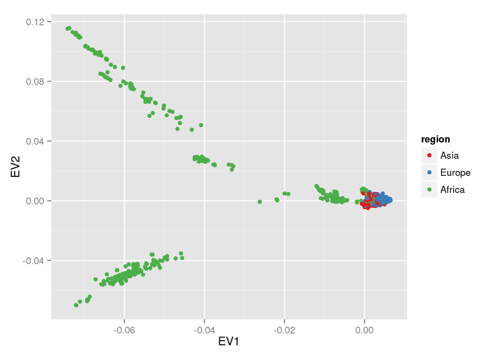

```r
gbhap$africa_breakdown<-apply(gbhap,1,function(x){if(x['region']=='Africa'){return(x['prefix'])}else{return(x['region'])}})


tab <- data.frame(sample.id = PCA$sample.id,
                  pop = gbhap[match(PCA$sample.id,gbhap$genbank_id),"region"],
                  pre = gbhap[match(PCA$sample.id,gbhap$genbank_id),"prefix"],
                  afronly = gbhap[match(PCA$sample.id,gbhap$genbank_id),"africa_breakdown"],
    EV1 = PCA$eigenvect[,1],    # the first eigenvector
    EV2 = PCA$eigenvect[,2],    # the second eigenvector
    stringsAsFactors = FALSE)
tab$region<- factor(tab$region, levels = c("Asia", "Europe", "Africa"))
tab$africa_breakdown<- factor(tab$africa_breakdown, levels = c("Asia", "Europe", "L0", "L1","L2","L3","L4","L5","L6"))


myColors <- brewer.pal(9,"Set1")
names(myColors) <- levels(tab$region)
colScale <- scale_colour_manual(name = "region",values = myColors)

ggplot(tab,aes(EV1,EV2))+geom_point(aes(color=region))+colScale
```

## Africa breakdown

The regional PCA is interesting. If we provide a breakdown just by Africa:

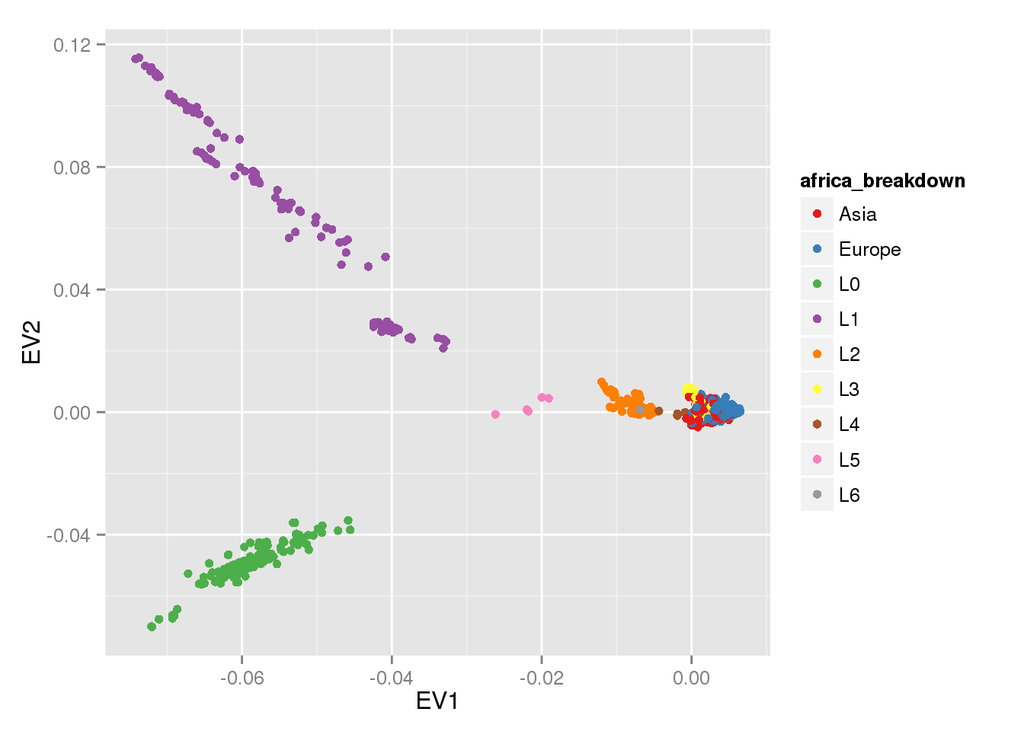

```r
names(myColors) <- levels(tab$africa_breakdown)
colScale <- scale_colour_manual(name = "africa_breakdown",values = myColors)
ggplot(tab,aes(EV1,EV2))+geom_point(aes(color=africa_breakdown))+colScale
```

```r
if(MASTER_SAMPLE_NUMBER & MASTER_SAMPLE_NUMBER<length(levels(factor(gbfac$genbank_id[gbfac$region=='Africa'])))){
  africa_only<-levels(factor(gbfac$genbank_id[gbfac$region=='Africa']))[sample(1:length(levels(factor(gbfac$genbank_id[gbfac$region=='Africa']))),MASTER_SAMPLE_NUMBER)]
}else{
  africa_only<-levels(factor(gbfac$genbank_id[gbfac$region=='Africa']))

}
my_subset<-africa_only
```

This makes more sense in light of [http://www.ncbi.nlm.nih.gov/pmc/articles/PMC2427203/bin/gr1.jpg]

## Africa only

Now let’s just at PCAs of Africa only

```r
PCA<-snpgdsPCA(genofile,autosome.only=FALSE,num.thread=16,eigen.cnt=2,sample.id = my_subset,snp.id = snp_subset)
```

```
## Principal Component Analysis (PCA) on SNP genotypes:
## Removing 6177 SNPs (monomorphic: TRUE, < MAF: NaN, or > missing rate: NaN)
## Working space: 3893 samples, 3869 SNPs
##  Using 16 (CPU) cores
## PCA: the sum of all working genotypes (0, 1 and 2) = 256360
## PCA: Thu Aug 13 11:05:24 2015    0%
## PCA: Thu Aug 13 11:05:27 2015    100%
## PCA: Thu Aug 13 11:05:27 2015    Begin (eigenvalues and eigenvectors)
## PCA: Thu Aug 13 11:07:08 2015    End (eigenvalues and eigenvectors)
```

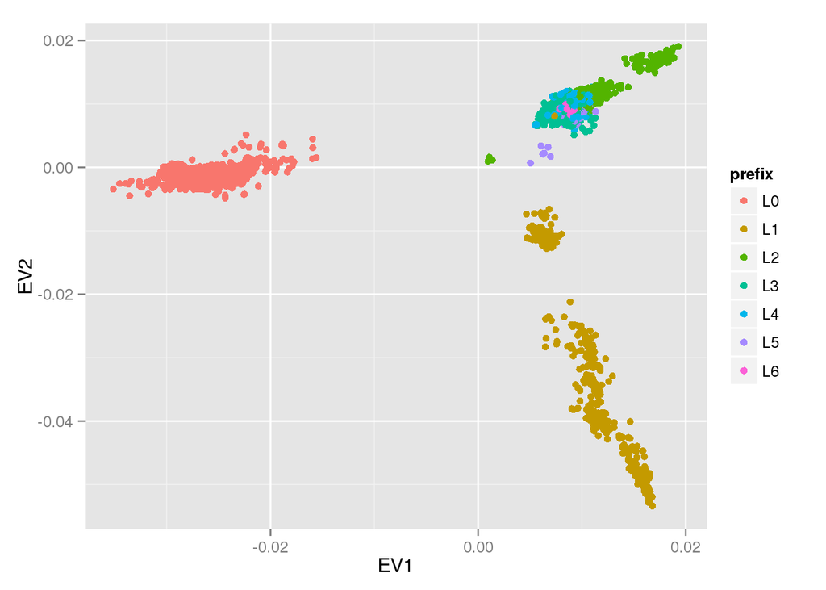

```r
tab <- data.frame(sample.id = PCA$sample.id,
                  pop = gbhap[match(PCA$sample.id,gbhap$genbank_id),"region"],
                  pre = gbhap[match(PCA$sample.id,gbhap$genbank_id),"prefix"],
    EV1 = PCA$eigenvect[,1],    # the first eigenvector
    EV2 = PCA$eigenvect[,2],    # the second eigenvector
    stringsAsFactors = FALSE)
ggplot(tab,aes(EV1,EV2))+geom_point(aes(color=prefix))
```

# Europe only

```r
if(MASTER_SAMPLE_NUMBER){
my_subset<-levels(factor(gbfac$genbank_id[gbfac$region=='Europe']))[sample(1:length(levels(factor(gbfac$genbank_id[gbfac$region=='Europe']))),MASTER_SAMPLE_NUMBER)]
}else{
  my_subset<-levels(factor(gbfac$genbank_id[gbfac$region=='Europe']))
}
```

```r
PCA<-snpgdsPCA(genofile,autosome.only=FALSE,num.thread=16,eigen.cnt=2,sample.id = my_subset,snp.id = snp_subset)
```

```
## Principal Component Analysis (PCA) on SNP genotypes:
## Removing 5662 SNPs (monomorphic: TRUE, < MAF: NaN, or > missing rate: NaN)
## Working space: 4500 samples, 4384 SNPs
##  Using 16 (CPU) cores
## PCA: the sum of all working genotypes (0, 1 and 2) = 111441
## PCA: Thu Aug 13 11:07:11 2015    0%
## PCA: Thu Aug 13 11:07:14 2015    89%
## PCA: Thu Aug 13 11:07:14 2015    100%
## PCA: Thu Aug 13 11:07:14 2015    Begin (eigenvalues and eigenvectors)
## PCA: Thu Aug 13 11:10:21 2015    End (eigenvalues and eigenvectors)
```

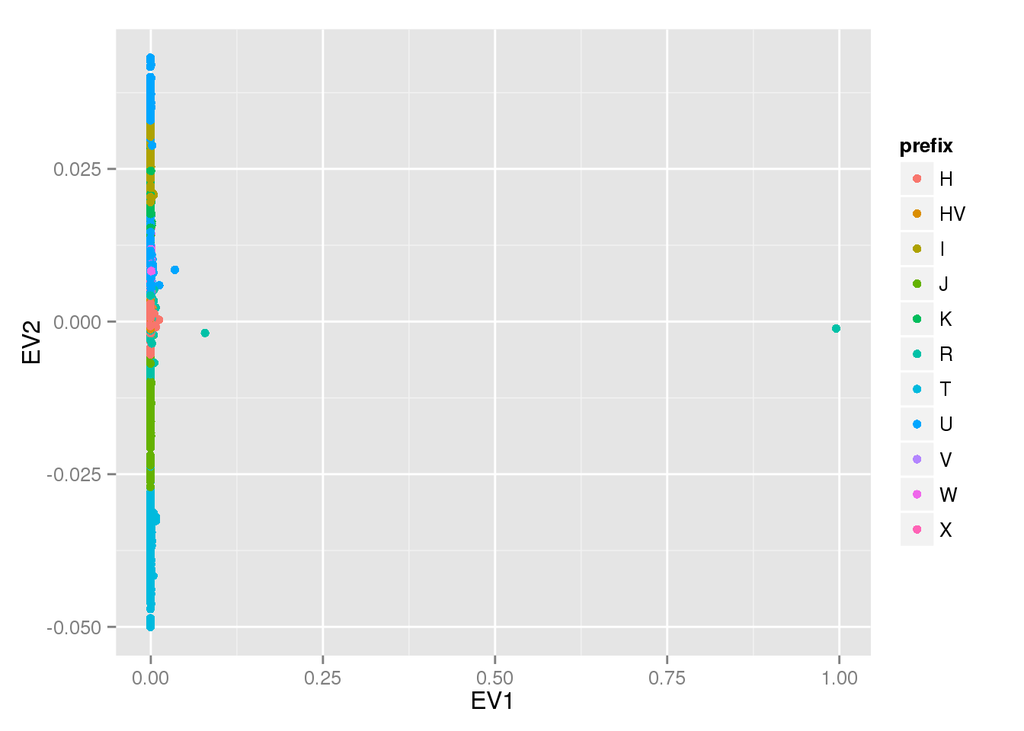

```r
tab <- data.frame(sample.id = PCA$sample.id,
                  pop = gbhap[match(PCA$sample.id,gbhap$genbank_id),"region"],
                  pre = gbhap[match(PCA$sample.id,gbhap$genbank_id),"prefix"],
    EV1 = PCA$eigenvect[,1],    # the first eigenvector
    EV2 = PCA$eigenvect[,2],    # the second eigenvector
    stringsAsFactors = FALSE)
ggplot(tab,aes(EV1,EV2))+geom_point(aes(color=prefix))
```

# Asia only

```r
if(MASTER_SAMPLE_NUMBER){
my_subset<-levels(factor(gbfac$genbank_id[gbfac$region=='Asia']))[sample(1:length(levels(factor(gbfac$genbank_id[gbfac$region=='Asia']))),MASTER_SAMPLE_NUMBER)]
}else{
  my_subset<-levels(factor(gbfac$genbank_id[gbfac$region=='Asia']))
}
```

```r
PCA<-snpgdsPCA(genofile,autosome.only=FALSE,num.thread=16,eigen.cnt=2,sample.id = my_subset,snp.id = snp_subset)
```

```
## Principal Component Analysis (PCA) on SNP genotypes:
## Removing 5090 SNPs (monomorphic: TRUE, < MAF: NaN, or > missing rate: NaN)
## Working space: 4500 samples, 4956 SNPs
##  Using 16 (CPU) cores
## PCA: the sum of all working genotypes (0, 1 and 2) = 168927
## PCA: Thu Aug 13 11:10:23 2015    0%
## PCA: Thu Aug 13 11:10:27 2015    79%
## PCA: Thu Aug 13 11:10:28 2015    100%
## PCA: Thu Aug 13 11:10:28 2015    Begin (eigenvalues and eigenvectors)
## PCA: Thu Aug 13 11:13:47 2015    End (eigenvalues and eigenvectors)
```

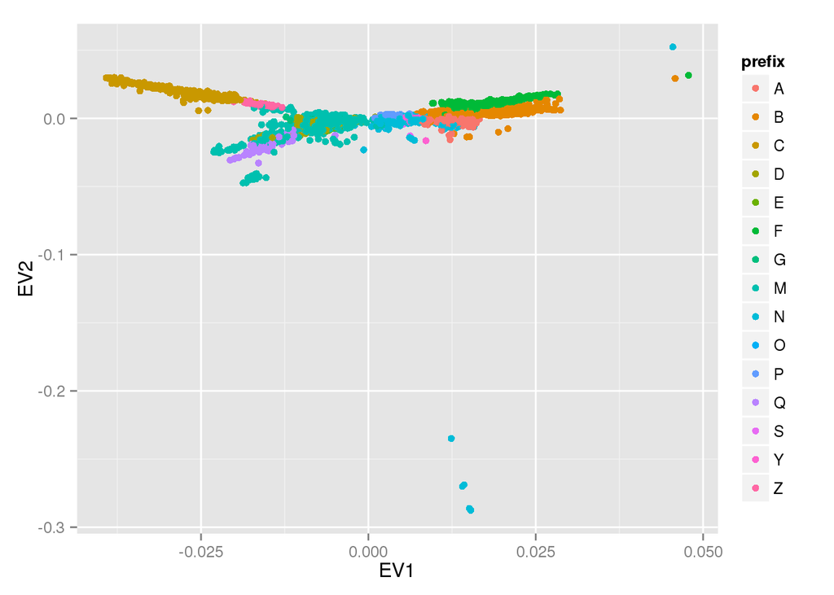

```r
tab <- data.frame(sample.id = PCA$sample.id,
                  pop = gbhap[match(PCA$sample.id,gbhap$genbank_id),"region"],
                  pre = gbhap[match(PCA$sample.id,gbhap$genbank_id),"prefix"],
    EV1 = PCA$eigenvect[,1],    # the first eigenvector
    EV2 = PCA$eigenvect[,2],    # the second eigenvector
    stringsAsFactors = FALSE)
ggplot(tab,aes(EV1,EV2))+geom_point(aes(color=prefix))
```

## Which regions have the most private mutations? i.e. how many haplogroups fall slightly outside of Phylotree?

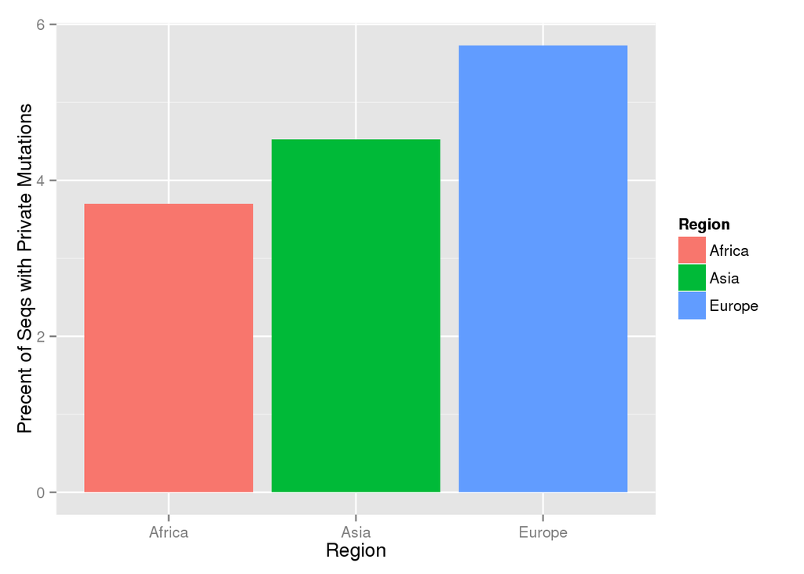

```r
private<-prop.table(table(str_detect(gbhap$haplogroup_verbose,'\\+'),gbhap$region),2)*100
private_df<-data.frame(Region=names(private[2,]),Private=private[2,],row.names=NULL)
ggplot(private_df,aes(Region,Private))+geom_bar(stat="identity",aes(fill=Region))+ylab("Precent of Seqs with Private Mutations")
```

```r
datatable(private_df)
```

|  | Region | Private |
| --- | --- | --- |
| 1 | Africa | 3.69894682763935 |
| 2 | Asia | 4.52421013273509 |
| 3 | Europe | 5.73196649581198 |

## Which haplogroups have the most private mutations?

```r
privatehap<-(prop.table(table(str_detect(gbhap$haplogroup_verbose,'\\+'),gbhap$prefix),2)*100)[2,]
privhapdf<-data.frame(Haplogroup=names(privatehap),Private=round(privatehap,digits=2),row.names=NULL)
datatable(privhapdf,rownames=FALSE,colnames=c("Haplogroup","Frac Private"))
```

| Haplogroup | Frac Private |
| --- | --- |
| A | 19.59 |
| B | 2.39 |
| C | 2.29 |
| D | 2.37 |
| E | 4.58 |
| F | 1.03 |
| G | 5.16 |
| H | 6.75 |
| HV | 7.16 |
| I | 0.22 |

[output cut: 23 more lines]

## Which haplogroups have the most singletons?

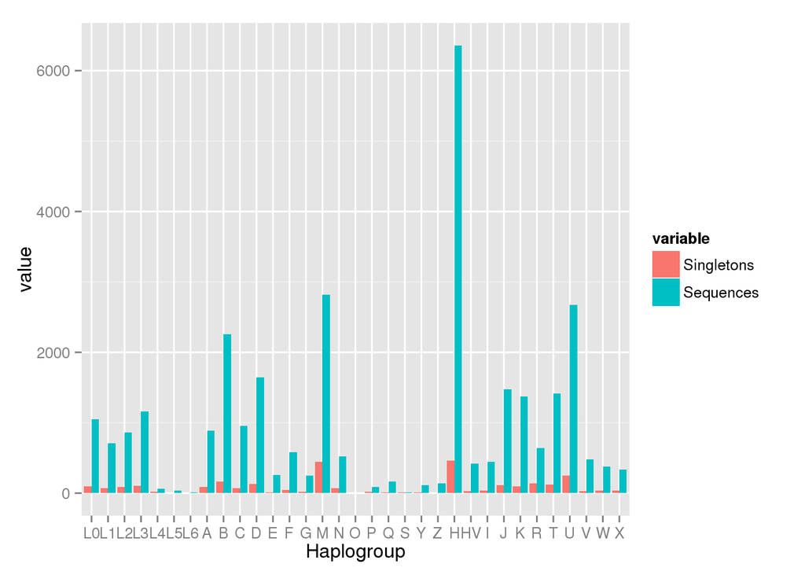

```r
gball %>% group_by(snpid) %>% summarize(sequences=n()) %>% filter(sequences==1) %>% select(snpid)-> singletonsnps
gball %>% filter(snpid %in% singletonsnps$snpid) %>% group_by(prefix) %>% summarize(singletons=n()) -> singletons
names(singletons)<-c("Haplogroup","Singletons")
singleton_anno<-merge(singletons,by_prefix_split,by="Haplogroup",all.y=TRUE)
singleton_anno$Singletons[is.na(singleton_anno$Singletons)]<-0

#this is not that great
singleton_melt <- melt(singleton_anno, id.vars=c('Haplogroup','Region'))
singleton_melt$Haplogroup<-factor(singleton_melt$Haplogroup,levels=by_prefix_split$Haplogroup)
ggplot(singleton_melt, aes(Haplogroup, value)) +
  geom_bar(aes(fill = variable), position = "dodge", stat="identity")
```

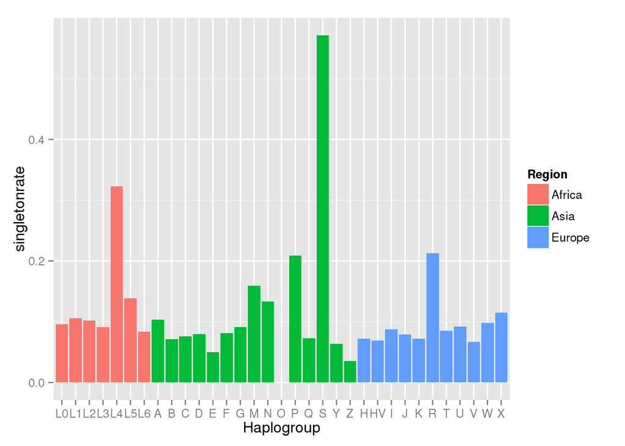

```r
singleton_anno$singletonrate<-singleton_anno$Singletons/singleton_anno$Sequences
singleton_anno$Haplogroup<-factor(singleton_anno$Haplogroup,levels=by_prefix_split$Haplogroup)
ggplot(singleton_anno,aes(Haplogroup,singletonrate)) + geom_bar(aes(fill = Region), position = "dodge", stat="identity")
```

# Disease

## Which regions have the most disease entries?

These are the proportion of disease variants among all variants for each of these populations. These are out of the more than 1 million variants among the entire set.

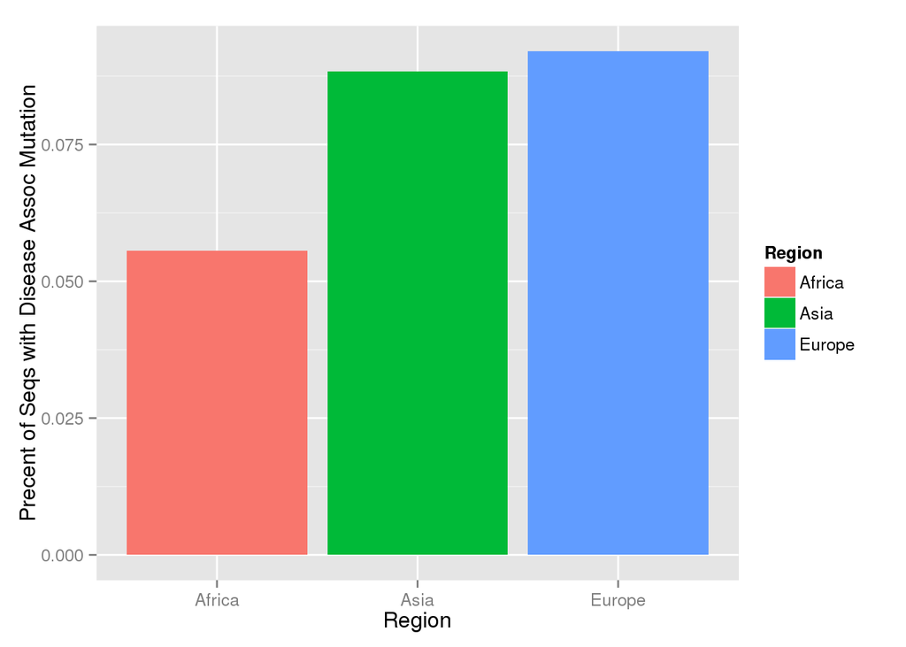

```r
disease<-prop.table(table(gball$ismmut,gball$region),2)
disease_df<-data.frame(Region=names(disease[2,]),Disease=disease[2,],row.names=NULL)
ggplot(disease_df,aes(Region,Disease))+geom_bar(stat="identity",aes(fill=Region))+ylab("Precent of Seqs with Disease Assoc Mutation")
```

## Which haplogroups have the most disease entries?

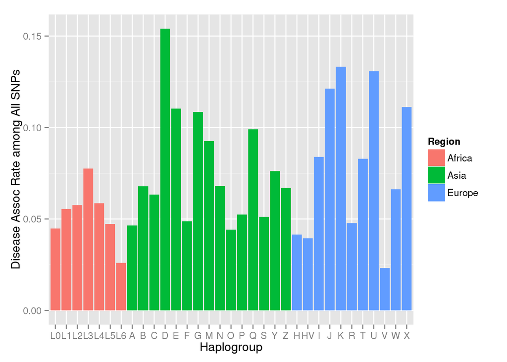

```r
hapdis<-prop.table(table(gball$ismmut,paste(gball$region,gball$prefix)),2)
hapdis_df<-data.frame(RegionPrefix=names(hapdis[2,]),Disease=hapdis[2,],row.names=NULL)

by_prefix_split<-cbind(colsplit(hapdis_df$RegionPrefix, ' ', names =  c('Region','Haplogroup')),hapdis_df$Disease)
names(by_prefix_split)<-c("Region","Haplogroup","Disease")

by_prefix_split$Haplogroup<-factor(by_prefix_split$Haplogroup,levels=by_prefix_split$Haplogroup)
ggplot(by_prefix_split,aes(Haplogroup,Disease))+geom_bar(stat="identity",aes(fill=Region))+ylab("Disease Assoc Rate among All SNPs")
```

## Individual diseases by region

Many diseases have very different rates by region.

These are dominated by MDD in Asia, altered brain pH in Europeans, LHON disorders all elevated in Europeans.

```r
gball$disease_anno<-ifelse(gball$disease=='','',paste(gball$disease,gball$snpid))
diseaserates<-round(prop.table(table(gball$disease_anno[gball$disease_anno!=''],gball$region[gball$disease_anno!='']))*100,digits=3)
dis_df<-data.frame(diseaserates)
datatable(dis_df,rownames=FALSE,colnames=c("Variant","Region","Freq"))
```

| Variant | Region | Freq |
| --- | --- | --- |
| AD / PD G5460A | Africa | 0.462 |
| AD T9861C | Africa | 0.018 |
| AD-weakly associated C309CC | Africa | 0.004 |
| AD, PD; MELAS A11084G | Africa | 0.004 |
| ADPD / Hearing Loss &amp; Migraine T4336C | Africa | 0 |
| ADPD / Possibly LVNC-cardiomyopathy associated A3397G | Africa | 0.001 |
| ADPD G3196A | Africa | 0.003 |
| Adult-Onset Dystonia A3796G | Africa | 0.011 |
| Adult-onset Encephalopathy / Ataxia G13063A | Africa | 0 |
| Alpers-Huttennlocher-like G7706A | Africa | 0 |

[output cut: 959 more lines]

## Which diseases segregate between Afr and Eur+Asia

```r
#table(gball$disease[gball$disease_anno!=''],gball$region[gball$disease_anno!=''])
#can we set up contigency tables
numAfr<-table(gbhap$region)[['Africa']]
numEur<-table(gbhap$region)[['Europe']]
numAsia<-table(gbhap$region)[['Asia']]

fishme<-function(x){
  afr<-as.numeric(x[['Africa']])
  afr_nosnp<-numAfr-afr

  nonafr<-as.numeric(x[['Europe']])+as.numeric(x[['Asia']])
  nonafr_nosnp<-numEur+numAsia-nonafr

  disease<-matrix(c(afr,nonafr,afr_nosnp,nonafr_nosnp),
       nrow = 2,
       dimnames = list(SNP = c("Afr", "Non-Afr"),
                       NoSNP = c("Afr", "Non-Afr")))
  fisher.test(disease, alternative = "two.sided")[['p.value']]
}

afr_disease_pvals<-apply(table(gball$disease_anno[gball$disease_anno!=''],gball$region[gball$disease_anno!='']),1,fishme)
adj_afr_disease_pvals<-p.adjust(afr_disease_pvals, method = 'BH')

#there are many that segregate by population
adj_afr_disease_pvals_below_thresh<-data.frame(Variant=sort(adj_afr_disease_pvals[adj_afr_disease_pvals<0.01]))
adj_afr_disease_pvals_below_thresh<-cbind(rownames(adj_afr_disease_pvals_below_thresh), adj_afr_disease_pvals_below_thresh)
datatable(adj_afr_disease_pvals_below_thresh,rownames=FALSE,colnames=c("Variant","Adj p-val"))
```

| Variant | Adj p-val |
| --- | --- |
| BD-associated / melanoma pts T195C | 0 |
| Diabetes / Cardiomyopathy / Endometrial cancer risk / mtDNA copy nbr / Metabolic Syndrome / Melanoma patients T16189C | 0 |
| MDD-associated G15043A | 0 |
| PD protective factor / longevity / altered cell pH / metabolic syndrome / breast cancer risk A10398G | 0 |
| Possibly LVNC-associated T2352C | 0 |
| Altered brain pH G12372A | 1.06643068143885e-267 |
| CPEO / Stroke / CM / Breast &amp; Renal &amp; Prostate Cancer Risk / Altered brain pH A12308G | 2.69597080641174e-254 |
| Altered brain pH A11467G | 8.16913988444103e-253 |
| MELAS / DEAF enhancer / hypertension / LVNC T3308C | 1.8734020280274e-224 |
| Cyclic Vomiting Syndrome with Migraine G16129A | 1.17770572595279e-206 |

[output cut: 97 more lines]

# Market basket

In most cases this type of analysis on SNPs alone will usually only reveal the existing haplogroup structure or (they simply identify the equivalent of tag SNPs), so it is perhaps most interesting when we view SNPs that span multiple regions and have low penetrance. It is conceivable that certain mutations convergent evolution toward similar combinations of SNPs that this can reveal.

If we combine it with phenotype it might be able to reveal combinations of SNPs that would escape GWAS, especially if we have a few haplogroups with elevated rates of a disease.

```r
imatrix<-as(numsparsey, "itemMatrix")
dimnames(imatrix)[[1]]<-levels(gbfac$genbank_id)
dimnames(imatrix)[[2]]<-levels(gbfac$snpid)

#rules <- apriori(imatrix)
#summary(rules)
#rules.sorted<-sort(rules,by="lift")

disease_snps<-str_extract(row.names(adj_afr_disease_pvals_below_thresh),'\\S+$')

getRules<-function(snp){
  rules <- apriori(imatrix,appearance = list(rhs=snp,default='lhs'))
  return(length(rules))
}

#disease_rules<-lapply(disease_snps[1:2],getRules)
```

# Conservation

There is little correlation between intra and inter species conservation at the gene level.

Here I calculated the level of conservation between all 39 species - which match the human residue at that position.

How many times do we see mutations in GenBank at that position.

```r
filename<-"mito-conservation-index/makeTables/39MSAs/35_CYTB.fa"
seqs<-readAAStringSet(filename)
str_extract(filename,"([0-9]+)_([A-Za-z0-9]+).fa")
```

```
## [1] "35_CYTB.fa"
```

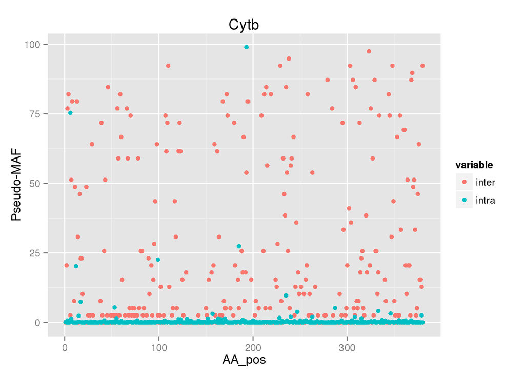

```r
matches<-str_match(filename,"([0-9]+)_([A-Za-z0-9]+).fa")
loci<-matches[2]
commonName<-matches[3]
seqMatrix<-as.matrix(seqs)
#i don't care for gaps
seqMatrix<-seqMatrix[,-which(seqMatrix[1,]=='-')]
of39<-apply(seqMatrix,2,FUN=function(x){length(which(x==x[1]))})
df<-data.frame(loci=loci,common=commonName,aa_pos=1:length(of39),of39=of39)
#write.table(df,file=outfile,sep="\t",quote=FALSE,row.names=FALSE)
#confirmRCSlen<-paste(seqMatrix[1,],collapse="")
#write(confirmRCSlen,file=paste('geneSizes/',commonName,':',str_length(confirmRCSlen),'bp',sep=""))
of39df<-data.frame(x=1:length(of39),inter=(39-of39)*100/39)


#try to put his in AA coords
genbank_count %>% filter(locus=='Cytb') %>% group_by(x=floor((pos-14749)/3)+1) %>% summarize(intra=sum(cnt)*100/nrow(gbhap)) -> cytb_conservation

bycytb<-merge(of39df,cytb_conservation,by="x",all.x=TRUE)
#no snps
bycytb[is.na(bycytb$intra),"intra"]<-0
melt_bycytb<-melt(bycytb,id="x")
ggplot(melt_bycytb,aes(x=x,y=value))+geom_point(aes(color=variable))+xlab("AA_pos")+ylab("Pseudo-MAF")+ggtitle("Cytb")
```